# Final Project

## Exploratory Analysis of Suicide Data Across Western Cultures

# Introduction

The purpose of this document is to analyze suicide data taken over three decades inside Western Countries. This analysis is done in hope to discover trends in suicide as to identify risk factors and identify factors that would put someone at higher risk of suicide. Such information is important in order to prevent future suicides and identify what kinds of factors may put someone at higher risk of committing suicide. It will also provide insight into whether suicide rates are rising or falling under our current cultural development.

# The Dataset

The dataset being used is a compiled set of data on suicide across multiple countries within the year range of 1985 and 2016. This dataset can be retrieved from the link below and only contains a single csv:

- https://www.kaggle.com/russellyates88/suicide-rates-overview-1985-to-2016
  - master.csv

The table includes 12 different attributes, notably containing things like:

- Country
- Year
- Sex
- Age Range
- Number of Suicides
- HDI for the year
- GDP for the year
- Etc.

# Step 1: Initial Data Analysis

Within this section we will create different data plots to analyze the trends within our data and see what kinds of relationships exist within it. This will inform us of what might be good trends to test later with hypothesis testing and regression tests.

We will be focusing specifically on Western Societies, filtering for mainland North America and the EU.

> Note we also remove the 2016 data as at the time of this dataset the year was incomplete

```r
library(tidyr)
library(dplyr)
```

```r
library(ggplot2)

# Reading in Data from csv repository to a usable dataframe
suicide_df <- read.csv("~/Documents/Spring 2019/CMSC 320/Final Project/Data/Suicides_data.csv")

# Creating lists of countries we are interested in
EU <- c("Austria", "Belgium", "Croatia", "Cyprus", "Czech Republic", "Denmark", "Estonia", "Finland", "France", "Germany", "Greece", "Hungary", "Ireland", "Italy", "Latvia", "Lithuania", "Luxembourg", "Matla", "Netherlands", "Poland", "Portugal", "Romania", "Slovakia", "Slovenia", "Spain", "Sweden", "United Kingdom")
 North_America <- c("United States", "Mexico", "Canada")

 # Filtering data to only contain those countries
filtered_df <- suicide_df %>%
  filter(country %in% EU |country %in% North_America ) %>%
  filter(year <= 2015)

head(filtered_df)
```

```
##   country year    sex         age suicides_no population suicides.100k.pop
## 1 Austria 1985   male   75+ years         152     156535             97.10
## 2 Austria 1985   male 55-74 years         355     584253             60.76
## 3 Austria 1985   male 35-54 years         515     940526             54.76
## 4 Austria 1985   male 25-34 years         232     548783             42.28
## 5 Austria 1985 female   75+ years         110     339223             32.43
## 6 Austria 1985   male 15-24 years         207     653728             31.66
##   country.year HDI.for.year gdp_for_year.... gdp_per_capita....
## 1  Austria1985        0.764   69,386,774,475               9759
## 2  Austria1985        0.764   69,386,774,475               9759
## 3  Austria1985        0.764   69,386,774,475               9759
## 4  Austria1985        0.764   69,386,774,475               9759
## 5  Austria1985        0.764   69,386,774,475               9759
## 6  Austria1985        0.764   69,386,774,475               9759
##        generation
## 1 G.I. Generation
## 2 G.I. Generation
## 3          Silent
## 4         Boomers
## 5 G.I. Generation
## 6    Generation X
```

Now that we have the dataset loaded we can start to look for trends in suicide rates based on different factors. We can start with something simple, say by plotting suicides over time to see if there is any type of relationship there. For this we want a scatter plot of the data plotted with a trend line, this can be achieved using the r ggplot() function and then add a trendline using geom_smooth(method=lm). Documentation for ggplot functionality can be found [here](https://ggplot2.tidyverse.org/reference/).

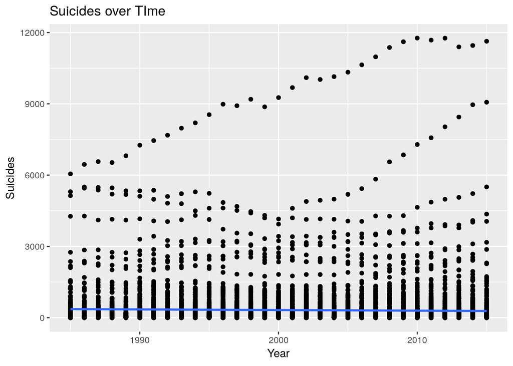

```r
# Using a pipeline and ggplot we can create a scatter plot of suicide rates over time
filtered_df %>%
  ggplot(aes(x = year, y = suicides_no)) +
  geom_point() +
  geom_smooth(method = lm)+
  labs(title = "Suicides over TIme",
       x = "Year",
       y = "Suicides")
```

The above graph is not very helpful as the data is clumped and there isn’t a clear picture of what is going on. We can try to get a clearer picture of the relationship between time and suicides by summarizing our data per year. We can do this by first combining each age group per country into one total number of suicides per year in each of our countries. Then we can take the average per year across all the countries to get a larger view of how suicides trend overall as time progresses.

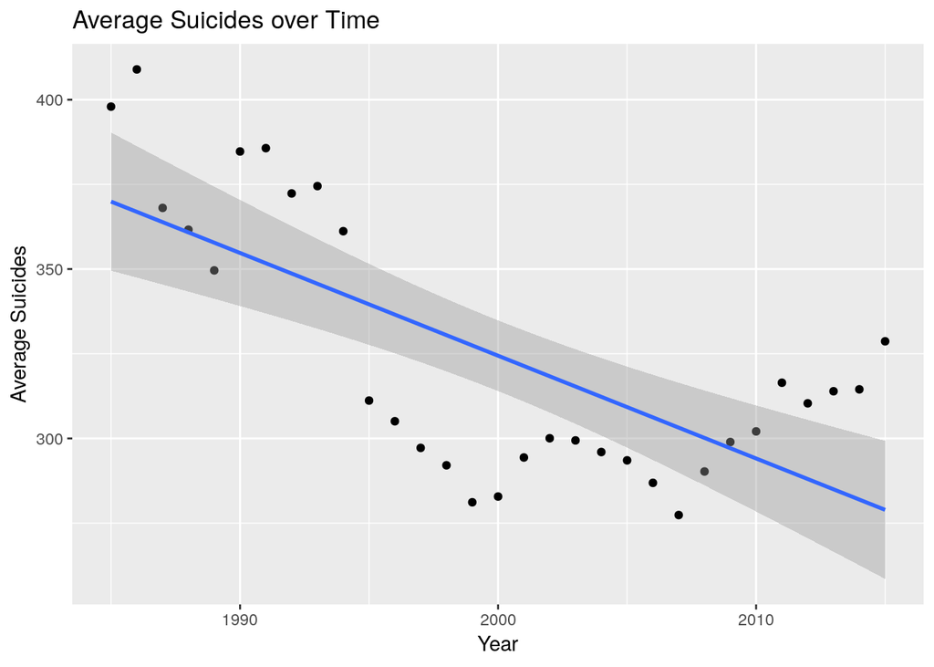

```r
# By first modifying the data then plotting against time we can get a better understanding
# of the relationship between suicides and time
filtered_df %>%
  group_by(year) %>%
  summarize(avg_suicides = mean(suicides_no)) %>%
  ggplot(aes(x = year, y = avg_suicides)) +
  geom_point() +
  geom_smooth(method=lm) +
  scale_y_continuous(labels = scales::comma) +
  labs(title = "Average Suicides over Time",
       x = "Year",
       y = "Average Suicides")
```

From the above graph we can observe a weak negative linear correlation between year and the average number of suicides, that is as time passes suicides seem to trend downwards. This seems to tell us that as time passes suicides tend to go down on average.

However this doesn’t look like a very strong correlation, as it has large variations, and we can attempt to find better predictors to discover more about the data, say looking at rates within different age groups rather than suicides over time. Since the age groups act more at categorical variables rather than a continuum in this data set and we care about occurrences within each group we can utilize a bar graph rather than a scatter plot. This will allow us to identify differences in suicide rates between the age groups represented in the data.

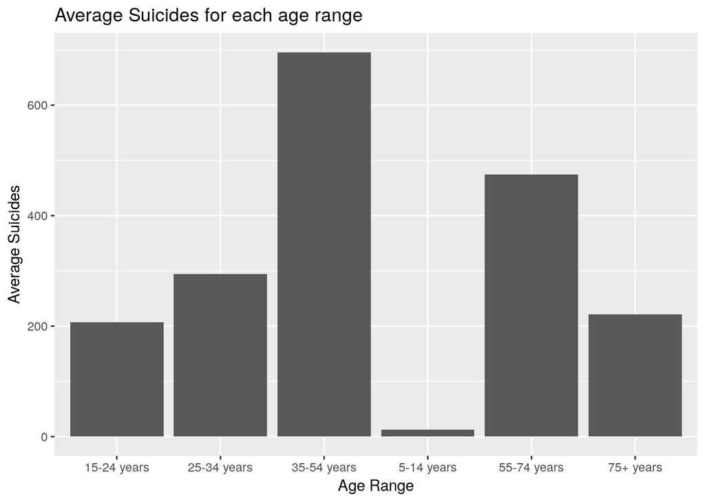

```r
# We first group over age and summarize the graph to get solidified numbers about suicides
# per age group. Then we fit it to a bar graph to see the discrepancies in occurrences
# between different age groups.
filtered_df %>%
  group_by(age) %>%
  summarize(suicides = mean(suicides_no)) %>%
  ggplot(aes(x = age, y = suicides)) +
  geom_bar(stat = "identity") +
  scale_y_continuous(labels = scales::comma) +
  labs(title = "Average Suicides for each age range",
       x = "Age Range",
       y = "Average Suicides")
```

The bar graph above shows that there is a clear discrapency between the different age groups and suicide rates. Where those within the age range of 35-54 seem to be much more at risk than the other age groups. We can use this data to help predict if a person is more at risk of suicide by assessing their age group’s rate of suicide and using this as part of a prediction strategy.

We can use this group information to create a new set of graphs, showing trends of suicide over time for each specific age group rather than everyone as a whole.

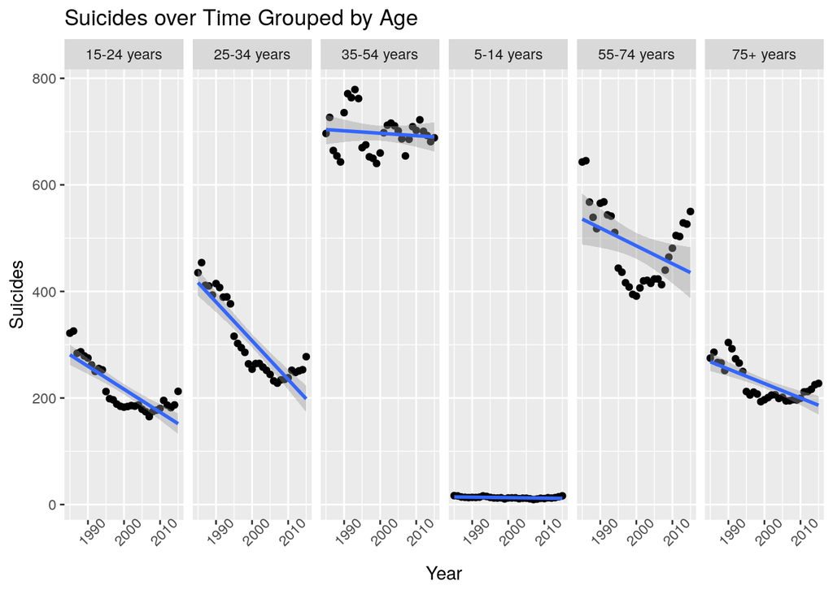

```r
# By first modifying the data then plotting against time we can get a better
# understanding of the relationship between suicides and time
filtered_df %>%
  group_by(year, age) %>%
  summarize(suicides = mean(suicides_no)) %>%
  ggplot(aes(x = year, y = suicides)) +
  facet_grid(~age) +
  geom_point() +
  geom_smooth(method=lm) +
  labs(title = "Suicides over Time Grouped by Age",
       x = "Year",
       y = "Suicides") +
  theme(axis.text.x = element_text(angle = 45))
```

The graphs above show tighter trends over suicide with time, showing that if we split the population into age groups we can better tell someone’s risk for suicide.

Another aspect that should be taken into account is a person’s gender. As within western cultures (and cultures in general), the role of a person can vary based off their gender.

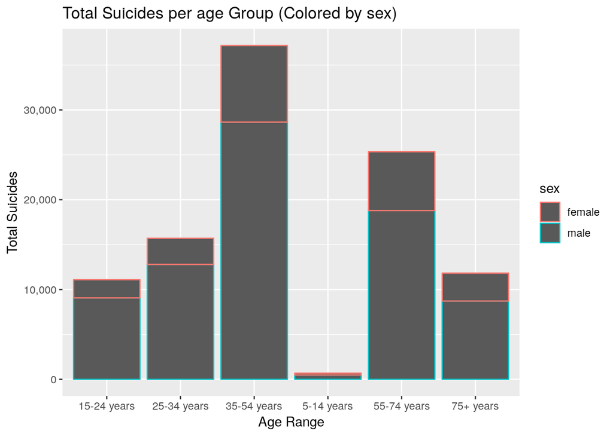

```r
# This time we add the extra grouping by sex in order to differentiate between men
# and women within each age group, allowing us to see which has a higher likelihood
# to commit suicide
filtered_df %>%
  group_by(country, age, sex) %>%
  summarize(total_suicides = sum(suicides_no)) %>%
  group_by(age, sex) %>%
  summarize(suicides = mean(total_suicides)) %>%
  ggplot(aes(x = age, y = suicides, color = sex)) +
  geom_bar(stat = "identity") +
  scale_y_continuous(labels = scales::comma) +
  labs(title = "Total Suicides per age Group (Colored by sex)",
       x = "Age Range",
       y = "Total Suicides")
```

With the added coloring based off sex we can also see that (with the exception of the 5-14 age range) on average the majority of each age group committing suicide appears to be men. This, at a glance, shows us that men are more at risk when it comes to suicide than women.

Now that we are aware of the clear relationship between age group and suicide and the discrepancies between genders we can use this to improve our estimation of suicide rates over time.

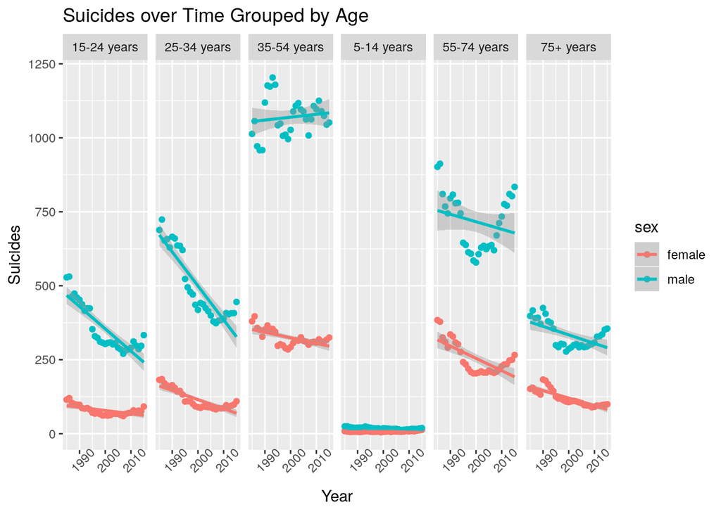

```r
# By first modifying the data then plotting against time we can get a better
# understanding of the relationship between suicides and time
filtered_df %>%
  group_by(year, age, sex) %>%
  summarize(suicides = mean(suicides_no)) %>%
  ggplot(aes(x = year, y = suicides, color = sex)) +
  facet_grid(~age) +
  geom_point() +
  geom_smooth(method=lm) +
  labs(title = "Suicides over Time Grouped by Age",
       x = "Year",
       y = "Suicides") +
  theme(axis.text.x = element_text(angle = 45))
```

Lastly, if we observe each of these we can see a slight upward trend in recent years so let’s look at this graph but only looking in the 21st century years (post-2000).

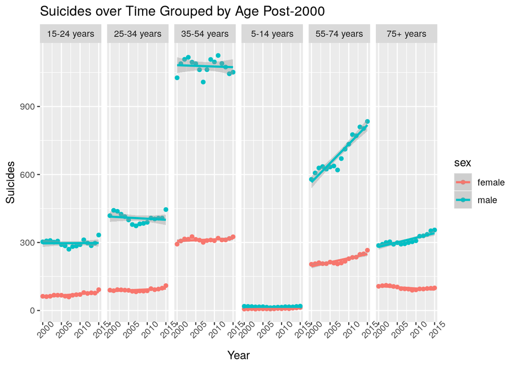

```r
# We can add a simple filter before modifying our data to make sure all the data is
# in the 21st century
filtered_df %>%
  filter( year >= 2000) %>%
  group_by(year, age, sex) %>%
  summarize(suicides = mean(suicides_no)) %>%
  ggplot(aes(x = year, y = suicides, color = sex)) +
  facet_grid(~age) +
  geom_point() +
  geom_smooth(method = lm) +
  labs(title = "Suicides over Time Grouped by Age Post-2000",
       x = "Year",
       y = "Suicides") +
  theme(axis.text.x = element_text(angle = 45))
```

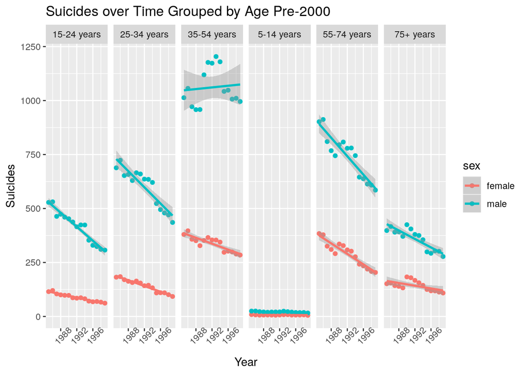

```r
# We can similarly do this for data before the 21st century

filtered_df %>%
  filter( year < 2000) %>%

  group_by(year, age, sex) %>%
  summarize(suicides = mean(suicides_no)) %>%
  ggplot(aes(x = year, y = suicides, color = sex)) +
  facet_grid(~age) +
  geom_point() +
  geom_smooth(method = lm) +
  labs(title = "Suicides over Time Grouped by Age Pre-2000",
       x = "Year",
       y = "Suicides") +
  theme(axis.text.x = element_text(angle = 45))
```

From the above two graphs, we can clearly see that going into the 21st-century suicide rates were steadily declining but once we crossed into the 21st century this changed and rates began to stagnate and even increase for some age groups.

# Step 2: Hypothesis Testing and Regression Modeling

Now that we have taken a look at our data and observed certain trends within it we can attempt to fit a regression model to suicide as to help predict the risk of an individual committing suicide. We can use this in a hypothesis testing scenario, that is I hypothesize that there is a significant relationship between time and suicides, within different sexes and age groups.

Since we want a model that can predict risk for people in the 21st century we will base our model off of the data in the 21st century (post-2000), as the trends in data seem to have shifted drastically since the turn of the century.

To begin we can start from the beginning like in Part 2 and simply base our model off of the passing of time, to see if years is a good estimator for suicide rates in the 21st century.

```r
# We first store our filtered data frame by filter out all years before 2000
twentyfirstst_df <- filtered_df %>%
  filter(year >= 2000)

# We create a model to predict the number of suicides off of just year
S_model <- lm(suicides_no~year, data=twentyfirstst_df)

# We use the Broom module to portray our model as a dataframe
broom::tidy(S_model)
```

```
## # A tibble: 2 x 5
##   term        estimate std.error statistic p.value
##   <chr>          <dbl>     <dbl>     <dbl>   <dbl>
## 1 (Intercept) -3859.     5169.      -0.747   0.455
## 2 year            2.07      2.57     0.805   0.421
```

Within null hypothesis testing, we set a standard alpha level (also known as rejection threshold) of 0.05. Meaning we want our p-value for the model to be smaller than our threshold. Based on the above data we can see year is not a good predictor for suicide occurrences by itself.

Explanations on why we choose 0.05 as standard alpha and more in-depth hypothesis testing can be found [here](http://www.hcbravo.org/IntroDataSci/bookdown-notes/experiment-design-and-hypothesis-testing.html).

To further stress this idea, let’s look at a graph of the residuals against the fitted values for this model. This graph will show us how well the model predicts the data by adhering to certain properties based on the assumptions of linear regression. We would expect a good model to have a residuals graph that is centered around 0 and has no obvious correlation between the x and y-axis.

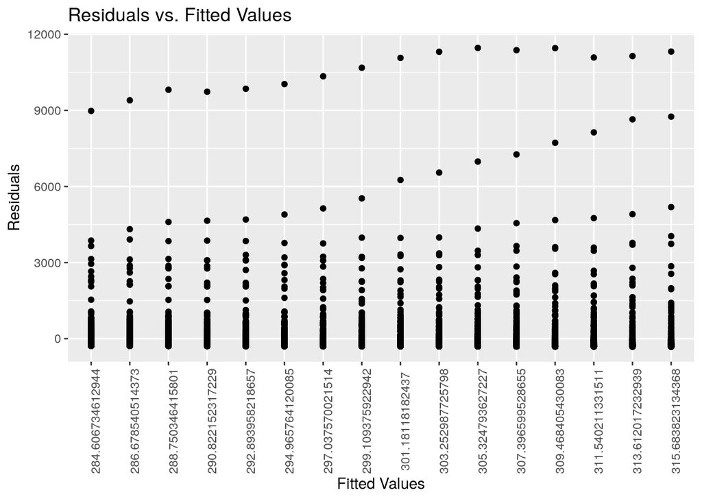

```r
# We first augment our model to pull out plottable values using the broom module
S_augment <- S_model %>%
  broom::augment()


# Using out agumented dataframe we can plot a graph of the residuals
S_augment %>%
  ggplot(mapping=aes(x=factor(.fitted), y=.resid)) +
  geom_point() +
  labs(title="Residuals vs. Fitted Values",
       x="Fitted Values",
       y="Residuals") +
  theme(axis.text.x = element_text(angle = 90))
```

The above graph for the year model clearly shows that the model does not fit the data well. Not only does the data not center at 0 but it also shows clear linear trends within itself. This tells us that year alone does not create a good model for suicide rates and we should look to other factors to help better predict suicide trends.

We can use the residuals to see what type of relationship year could have with them in order to more accurrately predict suicide rates. If a factor that is known to affect suicide chances has a trend within the residuals of the year only model then the factor most likely has an interaction with year. However, if this trend is not found the factor should be used as an additional predictor rather than one that has an interaction with year.

Documentation on the broom module used below can be found [here](https://www.rdocumentation.org/packages/broom/versions/0.5.2).

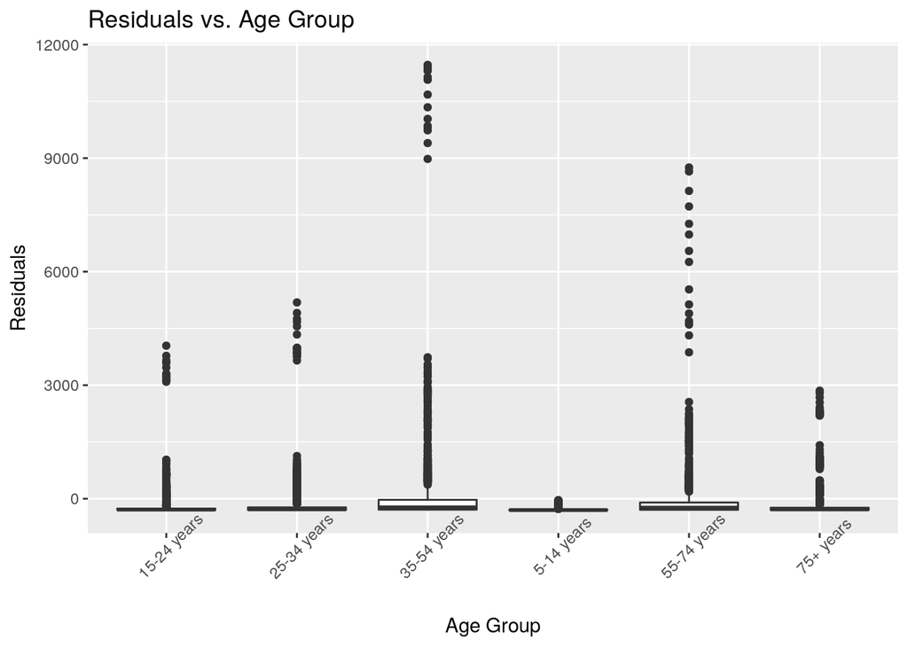

```r
# We first augment our model to pull out plottable values using the broom module
S_augment <- S_model %>%
  broom::augment()

# In order to use data from our original dataframe we have to join our model with our data.
joined_df <- S_augment %>%
  left_join(twentyfirstst_df, c("year", "suicides_no"))

# Using out agumented dataframe we can plot a graph of the residuals
joined_df %>%
  ggplot(mapping=aes(x= age , y=.resid)) +
  geom_boxplot()+
  labs(title="Residuals vs. Age Group",
       x="Age Group",
       y="Residuals") +
  theme(axis.text.x = element_text(angle = 45))
```

Explanations on relationships and predictors within linear models can be found [here](http://www.hcbravo.org/IntroDataSci/bookdown-notes/linear-regression.html).

With this new knowledge, we can create a new model that takes age into account alongside year.

```r
# We first store our filtered data frame by filter out all years before 2000
twentyfirstst_df <- filtered_df %>%
  filter(year >= 2000)

# We create a model to predict the number of suicides off of just year
S_model2 <- lm(suicides_no~year + age, data=twentyfirstst_df)

# We use the Broom module to portray our model as a dataframe
broom::tidy(S_model2)
```

```
## # A tibble: 7 x 5
##   term           estimate std.error statistic  p.value
##   <chr>             <dbl>     <dbl>     <dbl>    <dbl>
## 1 (Intercept)    -3976.     5002.      -0.795 4.27e- 1
## 2 year               2.07      2.49     0.831 4.06e- 1
## 3 age25-34 years    65.5      39.4      1.66  9.69e- 2
## 4 age35-54 years   512.       39.4     13.0   6.14e-38
## 5 age5-14 years   -171.       39.4     -4.34  1.44e- 5
## 6 age55-74 years   273.       39.4      6.92  4.97e-12
## 7 age75+ years      21.7      39.4      0.550 5.82e- 1
```

We can also look at the graph of the residuals to see if there was any improvement in the model.

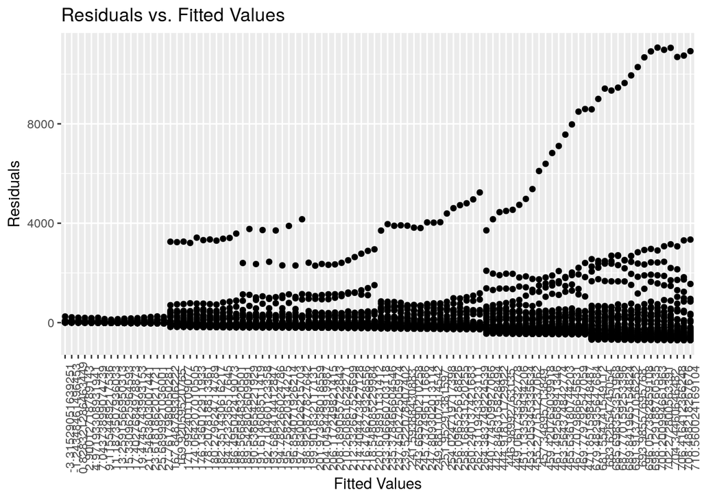

```r
# We first augment our model to pull out plottable values using the broom module
S_augment2 <- S_model2 %>%
  broom::augment()


# Using out agumented dataframe we can plot a graph of the residuals
S_augment2 %>%
  ggplot(mapping=aes(x=factor(.fitted), y=.resid)) +
  geom_point() +
  labs(title="Residuals vs. Fitted Values",
       x="Fitted Values",
       y="Residuals") +
  theme(axis.text.x = element_text(angle = 90))
```

The above graph now at least adheres to one property for a good residuals graph, being centered around 0. However, the graph does show a clear relationship between the fitted and residual values. This could infer that there is another factor affecting our model that is not taken into account.

From our analysis in Part 2, we also know that sex is a strong differentiator when it comes to suicide. Specifically, in Part 2, we showed men and women tend to have large differences in suicide rates even within the same age group, this would lead us to want to make a graph of sex against our residuals to see if sex as a predictor should be used in a relationship or its own predictor.

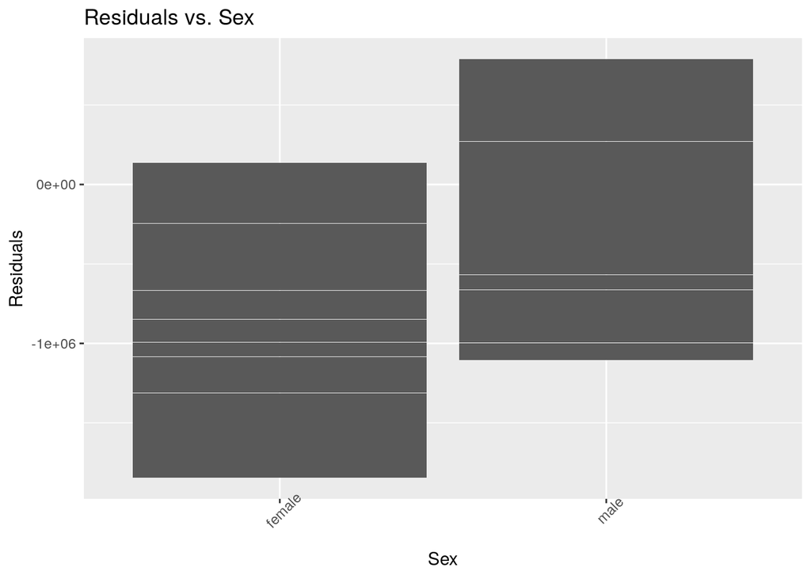

```r
# We first augment our model to pull out plottable values using the broom module
S_augment2 <- S_model2 %>%
  broom::augment()

# In order to use data from our original dataframe we have to join our model with our data.
joined_df2 <- S_augment2 %>%
  left_join(twentyfirstst_df, c("year", "suicides_no"))

# Using out agumented dataframe we can plot a graph of the residuals
joined_df2 %>%
  ggplot(mapping=aes(x= sex, y=.resid)) +
  geom_bar(stat="identity")+
  labs(title="Residuals vs. Sex",
       x="Sex",
       y="Residuals") +
  theme(axis.text.x = element_text(angle = 45))
```

Since there does seem to be a slight trend between sex and our residual values, shown by how female and male trends upward from one to another, we should add sex as a relational predictor rather than its own independent factor. Let’s see what the model looks like under this new addition.

```r
# We first store our filtered data frame by filter out all years before 2000
twentyfirstst_df <- filtered_df %>%
  filter(year >= 2000)

# We create a model to predict the number of suicides off of just year
S_model3 <- lm(suicides_no~year + age*sex, data=twentyfirstst_df)

# We use the Broom module to portray our model as a dataframe
broom::tidy(S_model3)
```

```
## # A tibble: 13 x 5
##    term                   estimate std.error statistic  p.value
##    <chr>                     <dbl>     <dbl>     <dbl>    <dbl>
##  1 (Intercept)            -4089.     4854.      -0.843 4.00e- 1
##  2 year                       2.07      2.42     0.857 3.92e- 1
##  3 age25-34 years            20.9      54.1      0.387 6.99e- 1
##  4 age35-54 years           242.       54.1      4.47  7.87e- 6
##  5 age5-14 years            -61.7      54.1     -1.14  2.54e- 1
##  6 age55-74 years           152.       54.1      2.80  5.08e- 3
##  7 age75+ years              29.9      54.1      0.553 5.80e- 1
##  8 sexmale                  227.       54.1      4.19  2.78e- 5
##  9 age25-34 years:sexmale    89.0      76.5      1.16  2.45e- 1
## 10 age35-54 years:sexmale   539.       76.5      7.05  2.04e-12
## 11 age5-14 years:sexmale   -219.       76.5     -2.86  4.22e- 3
## 12 age55-74 years:sexmale   243.       76.5      3.17  1.53e- 3
## 13 age75+ years:sexmale     -16.5      76.5     -0.216 8.29e- 1
```

We can also look at the graph of the residuals to see if there was any improvement in the model.

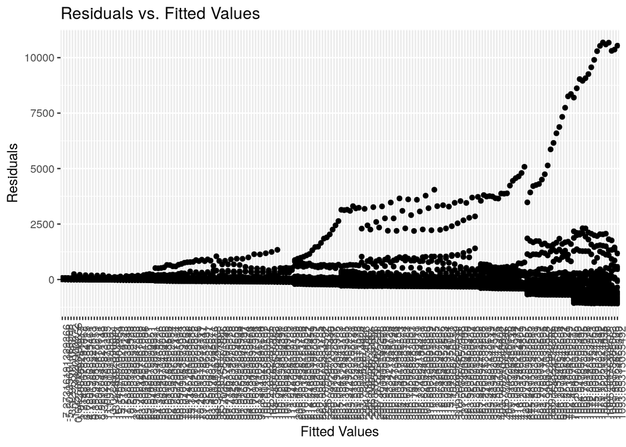

```r
# We first augment our model to pull out plottable values using the broom module
S_augment3 <- S_model3 %>%
  broom::augment()


# Using out agumented dataframe we can plot a graph of the residuals
S_augment3 %>%
  ggplot(mapping=aes(x=factor(.fitted), y=.resid)) +
  geom_point() +
  labs(title="Residuals vs. Fitted Values",
       x="Fitted Values",
       y="Residuals") +
  theme(axis.text.x = element_text(angle = 90))
```

We can further analyze our different models by performing an anova test on each in order to analyze their abilities to reject the null and minimize the residual sum of squares.

```r
anova(S_model, S_model2, S_model3)
```

```
## Analysis of Variance Table
##
## Model 1: suicides_no ~ year
## Model 2: suicides_no ~ year + age
## Model 3: suicides_no ~ year + age * sex
##   Res.Df        RSS Df Sum of Sq      F    Pr(>F)
## 1   5410 4049947665
## 2   5405 3789706281  5 260241384 78.857 < 2.2e-16 ***
## 3   5399 3563521729  6 226184552 57.114 < 2.2e-16 ***
## ---
## Signif. codes:  0 '***' 0.001 '**' 0.01 '*' 0.05 '.' 0.1 ' ' 1
```

The above anova test confirms our suspicions of our models improving with each iteration. The first model doesn’t even reject the null under the Anova, while the third better minimizes the RSS (residual sum of squares) over the second model, showing it better fits and predicts our data.

# Conclusions

While our models for predicting suicide off of these factors were not fully accepted, as our model for 75+ year olds failed to yield significant data, we can still utilize the models for other ages and genders. Also, with more data and possibly a lager time span moving into the future we could create stronger models for the other groups as well allowing us to better predict suicide risk based off gender, age, and year for individuals going forward. Suicide in Western Culture, as well as all cultures across the world, continues to be a large issue and by collecting data and conducting statistical analyses on this data will allow us to better prevent suicide in the future.

Utilizing these models we can tell that men are more likely to commit suicide than women are. Also, we can conclude that certain age groups are at higher risk of committing suicide then othes, specifically that those age 35-54 years old and 55-74 years old are at a higher risk than people outside those age ranges. Lastly, we can tell that in recent years suicides have been rising. This highlights a huge issue as something about our societiy’s development is driving people to suicide.

This data can be used to identify those most at risk of suicide. By identifying people who may be at risk we can better reduce the issue of suicide in our society by focusing on helping those groups who are most likely to commit suicide and work to lower suicide rates. Suicide is a growing issue in our society and data such as the data analyzed in this analysis can work to reduce the issue of suicide in society.

Further readings on this topic can be found on these sites, as well as more data:

- [World Health Organization](https://www.who.int/mental_health/suicide-prevention/en/)
- [Center for Disease Control](https://www.cdc.gov/violenceprevention/suicide/index.html)
- [National Institue of Mental Health](https://www.nimh.nih.gov/health/statistics/suicide.shtml)